# Analisis Pengaruh Durasi Film terhadap Total Revenue Rental pada Database Sakila

Faizah Leyla Bunga Mecca | M0725036 | Kelas D | Statistika 2025

2026-05-25

# Pendahuluan

## 1.1 Deskripsi Insight

Perkembangan teknologi informasi menjadikan data sebagai salah satu aset penting dalam mendukung pengambilan keputusan bisnis. Database Sakila merupakan database simulasi rental film DVD yang menyediakan berbagai informasi terkait pelanggan, transaksi rental, pembayaran, dan karakteristik film sehingga cocok digunakan untuk analisis bisnis berbasis data. Pada penelitian ini dilakukan analisis pengaruh durasi film terhadap total revenue rental untuk mengetahui apakah panjang durasi film memiliki hubungan terhadap pendapatan yang diperoleh perusahaan. Analisis dilakukan menggunakan bahasa pemrograman R melalui visualisasi data dan analisis regresi linear guna menghasilkan insight yang dapat membantu memahami pola perilaku pelanggan dalam memilih film serta mendukung strategi bisnis yang lebih efektif.

**Insight yang diambil:** Apakah durasi film berpegaruh terhadap total revenue rental pada database Sakila MySQL?

## 1.2 Tabel yang Digunakan

| Tabel | Fungsi |
| --- | --- |
| `film` | Menyimpan informasi film seperti judul dan durasi film |
| `inventory` | Menyimpan data stok/copy film yang tersedia untuk dirental |
| `rental` | Menyimpan data transaksi penyewaan film |
| `payment` | Menyimpan data pembayaran dari transaksi rental |

## 1.3 Metode

Metode analisis yang digunakan dalam penelitian ini adalah regresi linear sederhana untuk mengetahui pengaruh durasi film terhadap total revenue rental pada database Sakila MySQL. Regresi linear dipilih karena penelitian ini melibatkan satu variabel independen, yaitu durasi film (length), dan satu variabel dependen, yaitu total revenue rental. Data diperoleh dari penggabungan tabel film, inventory, rental, dan payment yang saling terhubung melalui relasi primary key dan foreign key. Melalui metode regresi linear sederhana, dapat diketahui arah hubungan, besar pengaruh, serta signifikansi pengaruh durasi film terhadap pendapatan rental. Model regresi yang digunakan dinyatakan dalam persamaan:

$$Y=β_0+β_1X+ε$$

Keterangan:

- $Y$ = total revenue
- $X$ = durasi film
- $β_0$ = intercept
- $β_1$ = pengaruh durasi film
- $ε$ = error

# Analisis Data

## 2.1 Pengambilan Data

Penelitian ini menggunakan data dari database Sakila dengan mengekstrak tabel film, inventory, rental, dan payment untuk menganalisis pengaruh durasi film terhadap total revenue rental. Tabel film digunakan untuk memperoleh variabel durasi film (length), tabel inventory sebagai penghubung antara film dan salinan fisiknya, tabel rental untuk mengetahui jumlah dan aktivitas transaksi penyewaan, serta tabel payment untuk mendapatkan total pendapatan dari setiap transaksi rental. Keempat tabel tersebut digabungkan melalui relasi primary key dan foreign key sehingga membentuk dataset terintegrasi yang kemudian digunakan sebagai dasar analisis regresi linear untuk melihat hubungan antara durasi film dan total pendapatan sewa.

```r
# Query SQL untuk mengambil data dari database Sakila kemudian di export menjadi file CSV
SELECT f.title, f.length,
    COUNT(r.rental_id) AS total_rental,
    SUM(p.amount) AS total_revenue
    FROM film f
    JOIN inventory i ON f.film_id = i.film_id
    JOIN rental r ON i.inventory_id = r.inventory_id
    JOIN payment p ON r.rental_id = p.rental_id
    GROUP BY f.title, f.length
```

```r
# Mengimport data ke R dari file CSV yang telah diexport dari database Sakila
df1 = read.csv("CM 1 SIM.csv")
ringkasan = head(df1)
knitr::kable(ringkasan, caption = "Ringkasan Data", col.names = c("title", "length", "total_rental", "total_revenue"))
```

Ringkasan Data

| title | length | total_rental | total_revenue |
| --- | --- | --- | --- |
| ACADEMY DINOSAUR | 86 | 23 | 36.77 |
| ACE GOLDFINGER | 48 | 7 | 52.93 |
| ADAPTATION HOLES | 50 | 12 | 37.88 |
| AFFAIR PREJUDICE | 117 | 23 | 91.77 |
| AFRICAN EGG | 130 | 12 | 51.88 |
| AGENT TRUMAN | 169 | 21 | 126.79 |

## 2.2 Analisis dengan Regresi Linear Sederhana

Analisis ini menggunakan regresi linear sederhana karena tujuan penelitian adalah untuk mengetahui dan mengukur pengaruh hubungan antara variabel independen berupa durasi film (length) terhadap variabel dependen berupa total revenue rental. Regresi linear sederhana dipilih karena kedua variabel bersifat kuantitatif dan memungkinkan untuk dianalisis hubungan liniernya, sehingga dapat diketahui seberapa besar perubahan pada durasi film memengaruhi perubahan pada total pendapatan sewa. Selain itu, metode ini juga efektif untuk melakukan prediksi dan memberikan gambaran arah serta kekuatan hubungan antar variabel berdasarkan data historis pada dataset Sakila yang telah diolah dari tabel film, inventory, rental, dan payment.

```r
model <- lm(total_revenue ~ length,
            data = df1)
summary(model)
```

```
##
## Call:
## lm(formula = total_revenue ~ length, data = df1)
##
## Residuals:
##     Min      1Q  Median      3Q     Max
## -64.665 -32.869  -7.988  25.359 161.506
##
## Coefficients:
##              Estimate Std. Error t value Pr(>|t|)
## (Intercept) 70.849541   4.135459  17.132   <2e-16 ***
## length      -0.004224   0.033795  -0.125    0.901
## ---
## Signif. codes:  0 '***' 0.001 '**' 0.01 '*' 0.05 '.' 0.1 ' ' 1
##
## Residual standard error: 42.31 on 956 degrees of freedom
## Multiple R-squared:  1.634e-05,  Adjusted R-squared:  -0.00103
## F-statistic: 0.01562 on 1 and 956 DF,  p-value: 0.9006
```

Dari output regresi linear yang telah didapatkan, persamaan modelnya adalah:

$$total_{revenue}=70.849541−0.004224(length)+ε$$
$$total_{revenue}=70.849541−0.004224×length$$

Kesesuaiannya:

- $Y$ (total revenue) → total_revenue
- $X$ (durasi film) → length
- $β_0$ (intercept) → 70.849541
- $β_1$ (koefisien length) → -0.004224
- $ε$ (error) → semua faktor lain yang tidak masuk model (termasuk residual)

## 2.3 Interpretasi Analisis

**A. Interpretasi persamaan**

- Intercept (70.85) berarti ketika durasi film = 0 (secara teoritis), maka rata-rata total revenue rental diprediksi sekitar 70.85. Walaupun secara konteks tidak realistis ada film berdurasi 0, nilai ini tetap berfungsi sebagai titik awal model.
- Koefisien length (-0.004224) menunjukkan bahwa setiap penambahan 1 menit durasi film, total revenue justru turun sekitar 0.0042 unit, namun nilai ini sangat kecil.

**B. Interpretasi signifikansi** Bagian p-value digunakan untuk melihat signifikansi pengaruh variabel.

Hipotesis:

- $H_0$ : Durasi film tidak berpengaruh terhadap total revenue.
- $H_1$ : Durasi film berpengaruh terhadap total revenue.

Kriteria:

- Jika p-value < 0.05 → H0 ditolak
- Jika p-value > 0.05 → H0 diterima

Berdasarkan uji regresi linear sederhana, nilai p-value = 0.9006 (jauh lebih besar dari 0.05) menunjukkan bahwa durasi film tidak berpengaruh signifikan terhadap total revenue rental. Artinya, secara statistik kita tidak memiliki bukti yang cukup bahwa panjang film memengaruhi pendapatan sewa.

**C. Interpretasi kekuatan model**

- R-squared = 0.00001634 (~0.0016%) menunjukkan bahwa hanya sekitar 0.0016% variasi total revenue yang dapat dijelaskan oleh durasi film.
- Sisanya (~99.998%) dipengaruhi oleh faktor lain di luar model. Ini menandakan model sangat lemah dalam menjelaskan hubungan kedua variabel.

**Kesimpulan**

Secara keseluruhan, hasil regresi menunjukkan bahwa durasi film hampir tidak memiliki pengaruh terhadap total revenue rental pada dataset Sakila. Dengan kata lain, faktor lain seperti jumlah rental, popularitas film, atau genre kemungkinan jauh lebih berperan dalam menentukan pendapatan dibandingkan durasi film.

# Visualisasi

## 3.1 Visualisasi Regresi Linear

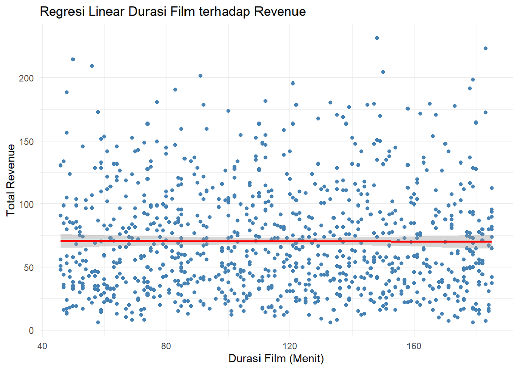

```r
library(ggplot2)

ggplot(df1, aes(x = length, y = total_revenue)) +
  geom_point(color = "steelblue") +
  geom_smooth(method = "lm",
              se = TRUE,
              color = "red") +
  labs(title = "Regresi Linear Durasi Film terhadap Revenue",
        x = "Durasi Film (Menit)",
        y = "Total Revenue") +
  theme_minimal()
```

**Interpretasi:** Berdasarkan visualisasi regresi linear sederhana menggunakan scatter plot, hubungan antara durasi film dan total revenue terlihat sangat lemah karena titik-titik data tersebar secara acak dan garis regresi cenderung mendatar. Hal ini menunjukkan bahwa peningkatan durasi film tidak memberikan pengaruh signifikan terhadap kenaikan revenue. Dengan demikian, durasi film bukan merupakan faktor utama yang menentukan besar kecilnya total revenue pada dataset tersebut.

## 3.2 Visualisasi Top 10 Film dengan Revenue Tertinggi

```r
class (df1)
```

```
## [1] "data.frame"
```

```r
top_film <- head(
  df1[order(-df1$total_revenue), ],
  10)
top_film
```

```
##                 title length total_rental total_revenue
## 842  TELEGRAPH VOYAGE    148           27        231.73
## 931         WIFE TURN    183           31        223.69
## 958         ZORRO ARK     50           31        214.69
## 349 GOODFELLAS SALUTE     56           31        209.69
## 731    SATURDAY LAMBS    150           28        204.72
## 856       TITANS JERK     91           29        201.71
## 860      TORQUE BOUND    179           27        198.72
## 382       HARRY IDAHO    121           30        195.70
## 437    INNOCENT USUAL    178           26        191.74
## 421     HUSTLER PARTY     83           22        190.78
```

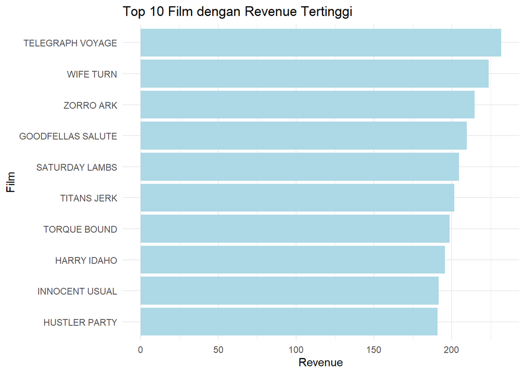

```r
ggplot(top_film, aes(x = reorder(title, total_revenue),y = total_revenue)) +
  geom_col(fill = "lightblue") +
  coord_flip() +
  labs(title = "Top 10 Film dengan Revenue Tertinggi",
        x = "Film",
        y = "Revenue") +
  theme_minimal()
```

**Interpretasi:** Berdasarkan visualisasi Top 10 Film dengan Revenue Tertinggi menggunakan bar chart, film TELEGRAPH VOYAGE memiliki total revenue tertinggi dibandingkan film lainnya, diikuti oleh WIFE TURN dan ZORRO ARK. Perbedaan panjang batang pada grafik menunjukkan adanya variasi revenue antar film, namun selisihnya tidak terlalu jauh. Visualisasi ini membantu menunjukkan film-film yang memberikan kontribusi revenue terbesar sehingga dapat digunakan untuk mengidentifikasi film dengan performa pendapatan terbaik pada dataset tersebut.

# Kesimpulan

**Insight yang didapat:** Durasi film tidak memiliki pengaruh signifikan terhadap total revenue rental pada database Sakila, sehingga faktor lain seperti popularitas film, genre, atau jumlah penyewaan kemungkinan lebih berperan dalam menentukan pendapatan rental.